# Statistical analysis of “Historically, the presidential inauguration has frequently been frigid in Washington”

Henry Linder (mhlinder@gmail.com)

January 13, 2017

In “[Historically, the presidential inauguration has frequently been frigid in Washington](https://www.washingtonpost.com/news/capital-weather-gang/wp/2017/01/10/historically-the-presidential-inauguration-has-been-a-frigid-day-in-washington-d-c/)”, Justin Grieser considers historical weather data for presidential election.

As a statistician, I think this type of small-data (twenty observations!) is great, and this illustrates my own belief that a “good” data analysis is one that situates data within a narrative and doesn’t mistake lots of numbers and statistical analysis for an interesting story.

On the other hand, as a statistician, I can’t resist the temptation to put to work the tools of my field. Specifically, I was curious about the author’s assertion, “Warmer inaugurations typically favor incoming Republican presidents.” I immediately wondered: does the data really support this conclusion?

I wasn’t able to directly download the numbers from the article, but I think ballpark guesses based on the bar charts are probably close enough for this type of back-of-the-envelope analysis.

A little setup in R gives us a nice little dataset with twenty observations.

```r
indata <-
    data.frame(year  = seq(2013, 1937, by = -4),
               party = factor(c("D", "D", "R", "R", "D", "D", "R",
                                "R", "R", "D", "R", "R", "D", "D",
                                "R", "R", "D", "D", "D", "D")),
               temp  = c(40, 38, 35, 36, 34, 40, 52, 7, 55, 28, 42,
                         35, 37, 23, 44, 48, 36, 34, 29, 33))
indata
```

```
##    year party temp
## 1  2013     D   40
## 2  2009     D   38
## 3  2005     R   35
## 4  2001     R   36
## 5  1997     D   34
## 6  1993     D   40
## 7  1989     R   52
## 8  1985     R    7
## 9  1981     R   55
## 10 1977     D   28
## 11 1973     R   42
## 12 1969     R   35
## 13 1965     D   37
## 14 1961     D   23
## 15 1957     R   44
## 16 1953     R   48
## 17 1949     D   36
## 18 1945     D   34
## 19 1941     D   29
## 20 1937     D   33
```

First, there’s no doubt that from a *numerical* perspective, Republican inaugurations are warmer on average than Democratic ones.

```r
## Subset based on political party
temp_D <- indata %>% filter(party == "D") %>% use_series(temp)
temp_R <- indata %>% filter(party == "R") %>% use_series(temp)

mean(temp_D)
```

```
## [1] 33.81818
```

```r
mean(temp_R)
```

```
## [1] 39.33333
```

But, is there statistical support for this conclusion?

I consider graphical plots of the data for each political party separately. The benchmark statistical technique to compare two different populations is a t-test, and for those paying attention at home, this type of analysis requires approximate normality of the two populations.

As a quick reminder, a normal distribution looks like a bell-shaped curve:

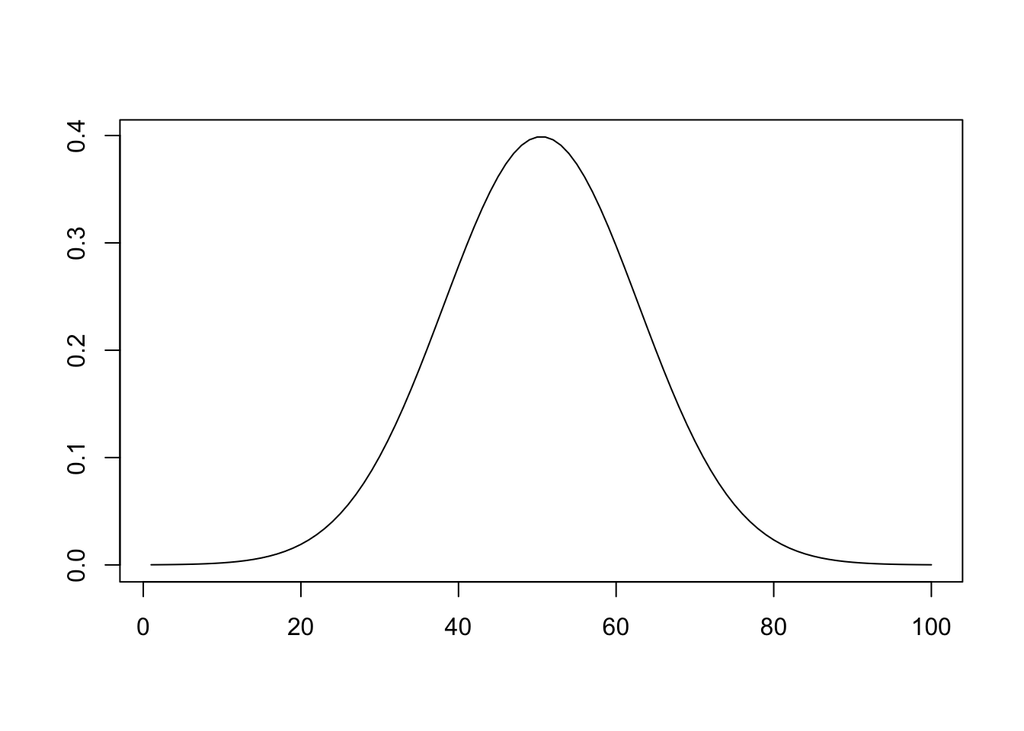

So, we can consider how well the temperature data matches this shape. Typically, we use a histogram for this purpose, but because the sample size is so small, this type of plot is difficult to read. A kernel density plot is slightly easier to read.

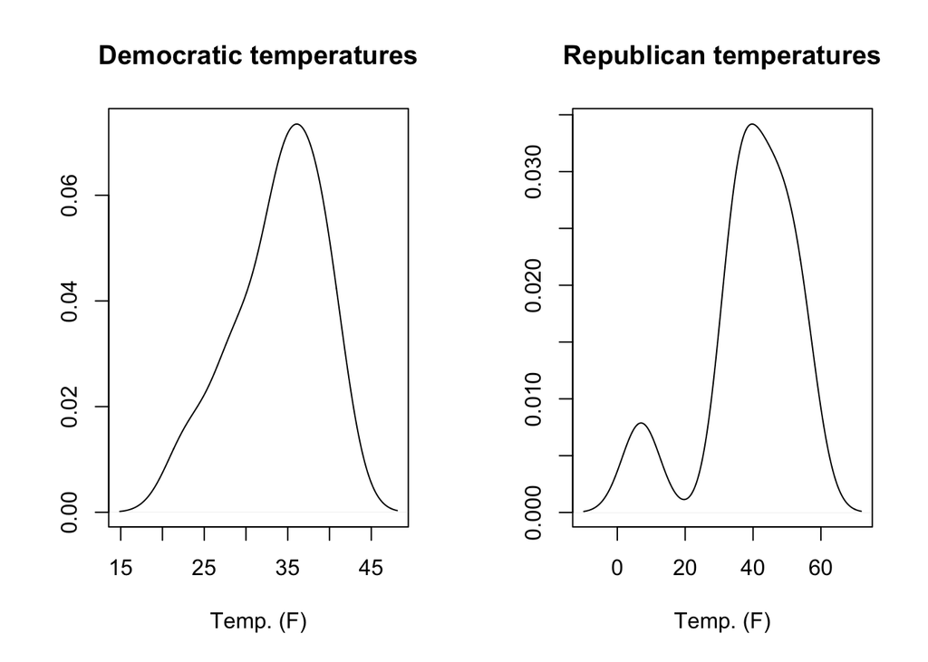

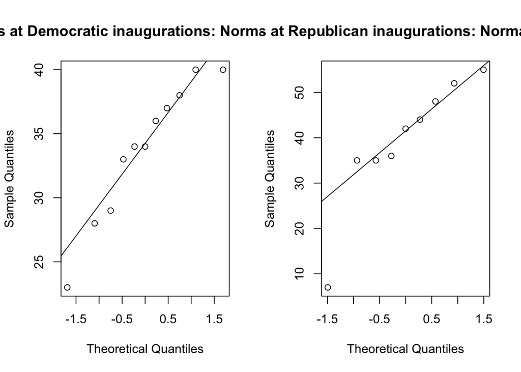

This paves the way for us to consider a t-test of **whether the average temperature at Democratic and Republican inaugurations is statistically different**:

```r
model <- t.test(temp ~ party, data = indata)
```

For a quick-and-dirty assessment, we can consider a 95% confidence interval for the true difference between the average temperatures for inaugurations of each party.

```r
model$conf.int
```

```
## [1] -16.646212   5.615909
## attr(,"conf.level")
## [1] 0.95
```

**If the averages are equal, their difference should equal zero**, and because the confidence interval includes zero, we conclude that **there is no statistical support for the conclusion that the average temperature on inauguration day is different for Republican and Democratic presidents.**

Considering the confidence interval in this case is equivalent to consider the (dreaded) p-value:

```r
model$p.value
```

```
## [1] 0.2949096
```

The p-value is larger than 0.05 (much larger!), so we conclude that the average temperatures are equal (and statistics professors everywhere cringed a little bit).

This analysis suggests that, on average, there is *no* difference in average temperature, which is unsurprising—it would be strange indeed if the temperature somehow differed by the President’s political party.

It’s also worth noting that because of the properties of the t-test, the small sample size means the difference between the observed averages would need to be very large to conclude that they are different, and if we were really concerned about this, I would recommend expand the scope of the analysis to include more historical data. This would require a more complicated model than a simple average, but might indicate additional structure in the data.

Finally, the author also cites National Weather Service forecasts for January 20, and gives some really interesting historical information. It is, of course, worth noting that is is well documented that weather forecasts at a horizon of more than six days are [unrealiable](http://www.nws.noaa.gov/ost/climate/STIP/RServices/huq_032509.htm), and are useful mainly as qualitative assessments, not exact point estimates.

That said, six of the twenty elections Grieser considers saw precipitation, which matches the NWS forecast of a “1 in 3 chance of measurable precipitation in the nation’s capital on Jan. 20.”